# Session 3+4: Introduction into R and Econometrics. Part D

2023-07-17

## Session 3+4 - Part D Endogeneity and Instrument Variables

## What we do in Session 3+4

- Properties of OLS
- Endogeneity and exogeneity
- Solutions to overcome endogeniety problems
  - Randomized experiments
  - Control variables
  - Sample split regressions
  - Instrument variables and 2SLS

## Properties of OLS

If five assumptions hold, then the OLS estimator \(\hat{\beta}_1\) is the **B**est **L**inear **U**nbiased **E**stimator (BLUE)

- *U*nbiased: If we run OLS with different random samples, the expected value of the estimated parameter equals the true (unknown)
- *B*est = Most efficient: OLS has the lowest variance of all estimators in the linear class
- *L*inear: OLS is in the class of linear models
- *E*stimator: From a sample, we try to make inference about the true value in the population parameter

## Five assumptions that give the BLUE property to the OLS estimator:

For future reference, it is useful to number these assumptions using the prefix “SLR” for simple linear regression.

- SLR.1: Linear in Parameters: \(y=\beta_0+\beta_1x+u\)
- SLR.2: Random Sampling of \(y\) and \(x\) from the population
- SLR.3: Variation in the sample values \(x_1,...,x_n\)
- SLR.4: Zero conditional mean: \(E(u|x)=E(u)=0\)
- SRL.5: The error \(u\) has the same variance given any value of the explanatory variable (homoscedasticity): \(Var(u|x)=\sigma^2\)

## Unbiased + Best (=efficient)

In a simulation of T random draws, OLS parameters will be

- correct on average (estimated \(\hat{\beta_1}\) centered around true \(\beta_1\))
- closest to the true values most often (lowest variance)

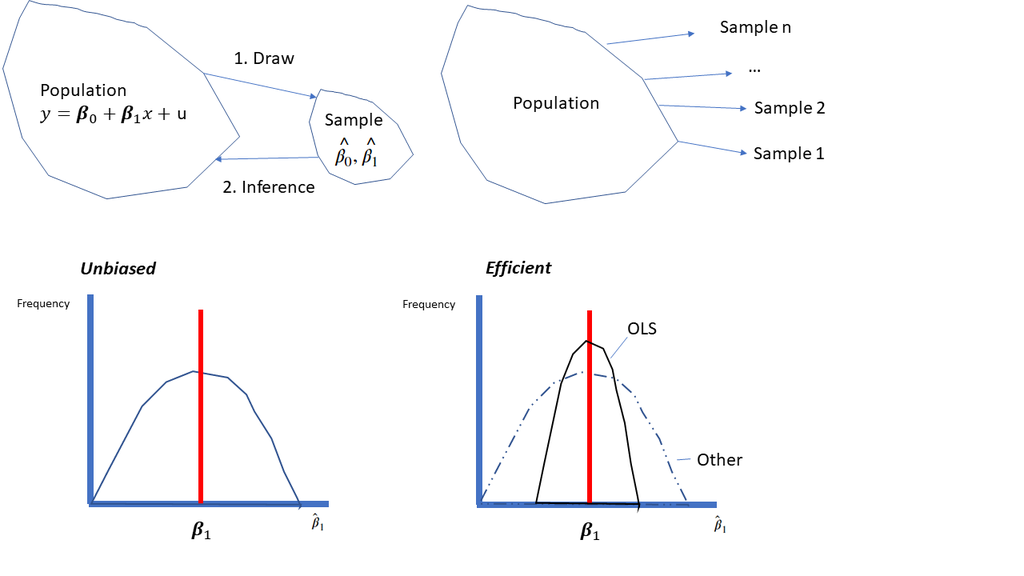

## Focus on assumption of unbiasedness

and not other violations: heteroskedasticity or autocorrelation

**Heteroskedasticity**: (non-constant) variance of \(u\) depends on \(x\)

- winter: low variation of demand shock and price (always 0)
- summer: high variation of shock and price (sunny / rainy)

**Autocorrelation**: persistent demand shocks across periods

Those are moderately important. If one of the two is violated

- the OLS estimator \(\hat{\beta}\) is still consistent but not efficient
- calculate standard errors using an appropriate formulas

## Exogenous and endogenous Variables

The most important assumption is exogeneity of variables \(x\).

- excluded variables not systematically correlated with \(x\)
- \(x\) is **exogenous**,
  - if uncorrelated with \(u\), i.e., \(\mbox{cor}(x_t,u_t)=0\)
- We say \(x\) is **endogenous**
  - if \(\mbox{cor}(x_t,u_t)\ne0\)

This is related to assumption SLR.4 \(\mathbb{E}(u|x)=\mathbb{E}(u)=0\)

- can only be satisfied if \(x\) is exogenous.

## The problem of endogeniety

If \(x\) is endogenous, the OLS estimator \(\hat{\beta}\) is biased.

- We typically check endogeniety as follows (intuitively):
  - Think which factors are part of the random shock \(u\)
  - Check if your \(x\) is correlated with factors in \(u\).

Ice cream example:

- Seasonal demand is part of the error term \(u\)
- Prices \(x\) correlated with seasonal demand
- because prices differ with high demand and low demand
- Thus, the correlation is not 0 and we have endogeneity

## “Problem” of the endogeneity problem

For real world data, we never observe \(u\)

- , i.e. we cannot simply see in the data that there is an endogeniety problem.
- if we compute the correlation between \(p\) and \(\hat{u}\) (the OLS residual),
  - we see that it is always 0
  - even if \(u\) and \(p\) are correlated.
- So arguing that there is endogeneity is a verbal exercise

However, we now use simulated data to outline the issue.

## Exploring Endogeniety in R

We consider again our simulated data for ice cream demand

- case 1: prices depend on unobserved demand shocks
  - Is the OLS estimator biased? Is there endogeneity?
  - Hint: think of correlation between \(u\) and \(p\)
- case 2: eliminating the demand shocks
- case 3: firms charge constant markups

## First define the model

```r
T=1000
b1 = 100
b2 = -1

# demand shock
eps = rnorm(n = T,mean = 0,sd = 5)

# costs
c=runif(T,min = 10,max = 30)

# equation for optimal prices
p = (b1 + eps)/(2*b2)  + c / 2

# demand function
q = b1 + eps - b2*p
```

## Now we run a regression

What do you think of this relation?

```r
lm(q~p)
```

```
##
## Call:
## lm(formula = q ~ p)
##
## Coefficients:
## (Intercept)            p
##     64.2818       0.1107
```

## Correlation: prices and error term

By construction the error term \(u\)

- is zero on average
- has zero correlation with \(p\)

```r
model <- lm(q~p)
u <- residuals(model)

mean(u)
```

```
## [1] 1.606488e-16
```

```r
cor(p,u)
```

```
## [1] -3.675865e-16
```

## Correlation: prices and demand shock

But we do know that \(p\) depends on demand shock \(eps\).

```r
cor(p,eps)
```

```
## [1] -0.6674776
```

And indeed we find a negative correlation.

- This \(eps\) is in error term creating a bias
- We can rewrite: \(u=eps+v\)
- \(u\) depends on a part
  - \(eps\) correlated with \(p\)
  - \(v\) uncorrelated with \(p\)

## We reduce the the demand shock \(eps\)

Consider in your simulation the limit case that \(\sigma_{u}\rightarrow 0\).

- What is then the main source of variation in prices?
- To which value will \(cor(p,eps)\) converge?
- To which value will \(cor(p,u)\) converge?
  - (the real \(u\) not the constructed \(u\))

We study in the simulation whether the OLS estimator of prices seems to be unbiased in this limit case.

## Set demand shock equal to zero

```r
T=1000
b1 = 100
b2 = -1

# demand shock
eps = rnorm(n = T,mean = 0,sd = 0.0005)

# costs
c=runif(T,min = 10,max = 30)

# equation for optimal prices
p = (b1 + eps)/(2*b2)  + c / 2

# demand function
q = b1 + eps - b2*p
```

Prices affected by market size, price sensitivity, and costs and not the demand shock

## Set demand shock equal to zero

Are we now close to the true values?

```r
lm(q~p)
```

```
##
## Call:
## lm(formula = q ~ p)
##
## Coefficients:
## (Intercept)            p
##         100            1
```

## Set demand shock equal to zero

```r
model<-lm(q~p)
u<-residuals(model)

cor(p,u)
```

```
## [1] -2.986036e-16
```

```r
cor(p,eps)
```

```
## [1] 0.04088776
```

we get consistent parameters of \(b0\) and \(b1\)

- when no correlation between \(p\) and \(eps\)

## Constant markup model

We now assume prices \(p\) always set 10% above the cost \(c\)

- prices are just a constant markup above costs
- and uncorrelated with the demand shock

Two questions for you:

- Are prices \(p\) then endogenous or exogenous?
- Is the OLS estimator biased?

## Define the new model

```r
T=1000
b1 = 100
b2 = -1

# demand shock
eps = rnorm(n = T,mean = 0,sd = 5)

# costs
c=runif(T,min = 10,max = 30)

# equation for optimal prices
p = 1.1*c

# demand function
q = b1 + eps - b2*p
```

## Constant markup model

Do we find consistent estimates?

```r
lm(q~p)
```

```
##
## Call:
## lm(formula = q ~ p)
##
## Coefficients:
## (Intercept)            p
##      99.462        1.016
```

## Some methods to consistently estimate causal effects

We will discuss several methods that could be used to overcome endogeniety problems in order consistently estimate regression parameters that describe causal effects (like the slope of a demand function).

- Conduct a randomized experiment.
- Add control variables
- Sample split regressions
- Use instrumental variable estimation.

## Conduct a Randomized Experiment

Ideal method to get a causal effect *(Scientific Gold Standard)*

Pharmaceutical companies who want to register new drugs

- we randomly select two groups, i.e., they are identical
- we give one group the medication (treatment)
- and the other receives a placebo (control)
- both identical groups only differ in outcome of treatment

However, not always possible, or too costly, to randomize

- We thus need other approaches

## Control variables: Motivating example

Assume the demand function for ice is given by the following (*long*) regression formula with two explanatory variables:

\[q_t = \beta_0 + \beta_1 p_t + \beta_2 s_t + v_t\] where \(s_t\) is a dummy variable that is 1 if the day is sunny and 0 otherwise and \(u_t\) are unobserved demand shocks.

Assume we estimate the (*short*) regression model: \[q_t = \beta_0 + \beta_1 p_t +u_t\] If data was generated by the long model, it must hold that \[u_t = \beta_2 s_t + v_t\]

## Question for you

Is \(\beta_1\) biased if we estimate the short regression via OLS?

- \(s\) is part of the error term \(u\) if omitted from the regression
- Since \(p\) is correlated with \(s\), \(p\) is then correlated with \(u\)
- We have an endogeneity problem and a biased estimator.

## Create data with seasonality (0/1)

```r
T=1000
b0 = 100
b1 = -1
b2 = 20

# create uncorrelated + independent error term v
v = rnorm(T,0,5)

# seasonality (random variable of 0/1 for hot or not hot)
s = sample(x = c(0,1),size = T,replace = TRUE)

# equation for optimal prices
p = 10*s + runif(T,20,30)

# demand function
q = b0 + b1*p + b2*s + u

# error term with omitted variable seasonal dummy
u = b2*s + v
```

## Output of short regression

Are coefficients biased and do we have \(cor(p,u)=0\)?

```r
# short regression
lm(q~p)
```

```
##
## Call:
## lm(formula = q ~ p)
##
## Coefficients:
## (Intercept)            p
##     65.4349       0.4785
```

```r
cor(p,u)
```

```
## [1] 0.7758292
```

## Output of long regression

Are coefficients biased and do we have \(cor(p,u)=0\)?

```
##
## Call:
## lm(formula = q ~ p + s)
##
## Coefficients:
## (Intercept)            p            s
##         100           -1           20
```

## Random price experiment

it is not important that excluded variables are correlated with dependent variable of demand,

it is important that none of the stuff we leave out is correlated with prices

## To see that create uncorrelated prices

```r
T=1000
b0 = 100
b1 = -1
b2 = 20

# error term
v = rnorm(T,0,5)

# seasonality (random variable of 0/1 for hot / not hot)
s = sample(c(0,1),T,replace = TRUE)

# equation for optimal prices
p = runif(T,20,30)

# demand function
q = b0 + b1*p + b2*s + v
```

## … and run the short regression

```
##
## Call:
## lm(formula = q ~ p)
##
## Coefficients:
## (Intercept)            p
##    106.1569      -0.8455
```

we see it is important that prices are not correlated with unobserved factors in the error term

## Control variables

if observed variables are correlated with the error term

- We can now just include them in the regression as controls

By adding control variables, we

- remove factors from the error term and
- make our explanatory variable of interest exogenous.

## Exogeneity in regressions with controls

If we estimate the short regression \[q_t = \beta_0 + \beta_1 p_t +u_t\] where \[u_t = \beta_2 s_t + v_t\]

\(p\) is endogenous if it is correlated with \(u\) through \(s\)

- Assume we add \(s\) as control variable and estimate

  \[q_t = \beta_0 + \beta_1 p_t + \beta_2 s_t + u_t\]

\(p\) is exogenous if uncorrelated with \(v\), even if correlated with \(s\).

## Which control variables to add?

Assume you want to study the size of wage *discrimination* against females.

- the regression is wage on female dummy variable
- add as control variable type of job to your regression?

Assume you want to analyse the effect of obtaining a university degree on wages.

- the regression is wage on university degree
- add as control variable the high-school grades?

## Separate regressions for subsets

Consider again the ice cream demand function

\[q = \beta_0 + \beta_1 p + \beta_2 s + u\]

- where \(s\) is a dummy that is 1 if it is sunny and 0 otherwise.
- We assume \(s\) affects the price \(p\) but \(u\) is uncorrelated with \(p\).

Alternative way to control for \(s\): estimate separate regressions,

- each using only observations with the same value of \(s\)

## Separate regressions for subsets

Control by separate regressions for subsets of the data

- First, we only take the observations where \(s_t=0\): \[q = \beta^0_0 + \beta^0_1 p + u\]
- Then we only take the observations where \(s_t=1\): \[q = \beta^1_0 + \beta^1_1 p + u\]

The slope estimates \(\hat \beta^0_1\) and \(\hat \beta^1_1\) of both regressions are consistent estimates of \(\beta_1\) and the difference in estimated constants \(\hat \beta^1_1\)- \(\hat \beta^0_1\) is a consistent estimate of \(\beta_2\).

## We show this in R

```r
dat = data.frame(q=q,p=p,s=s)

# use filter from package dyplr
library(dplyr)

# first data subsample s=0
dat0 = filter(dat, s==0)

# second data subsample s=1
dat1 = filter(dat, s==1)
```

```r
# short regression for subsample s=0
lm(q~p, dat0 )
```

```
##
## Call:
## lm(formula = q ~ p, data = dat0)
##
## Coefficients:
## (Intercept)            p
##     99.7211      -0.9914
```

```r
# short regression for subsample s=1
lm(q~p , dat1)
```

```
##
## Call:
## lm(formula = q ~ p, data = dat1)
##
## Coefficients:
## (Intercept)            p
##    116.9098      -0.8673
```

## Endogeneity without observing control

As discussed, omitting variables which are correlated with our \(x\)

- results in a violation of \(\mathbb{E}(u|x)=\mathbb{E}(u)=0)\)
- but sometimes we do not have a good control variable
- e.g., we do not observe high/low demand shocks

**Instrumental variables (IV)** solve the endogeneity issues

- unbiased estimator of the unknown causal coefficients
  - when \(x\) is correlated with the error term \(u\).

## Instrumental Variable Regression

To understand how IV regression works, think of the variation in \(x\) as having two parts:

- one part that, for whatever reason, is correlated with \(u\) (this is the part that causes the problems) and
- a second part that is uncorrelated with \(u\).
- If you had information that allowed you to isolate the second part, you could focus on those variations in \(x\) that are uncorrelated with \(u\) and disregard the variations in \(x\) that bias the OLS estimates.

## Grapical illustration 1

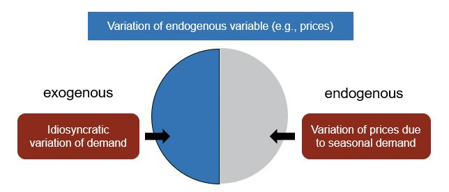

## Grapical illustration 2

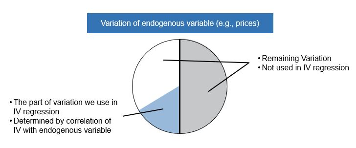

## An instrumental variable…

or short, instrument, \(z\) for an endogenous variable \(x\) is a variable that satisfies the following two conditions:

- Relevance: \(z\) is correlated with the endogenous variable \(x\)
  - \(cor(p,z)\neq 0\)
- Exogeneity: \(z\) is not correlated with the disturbance \(u\)
  - \(cor(z,u)=0\)

Per endogenous variable in the regression model,

- at least one instrument that is not part of the model

## Graphical illustration of the two conditions

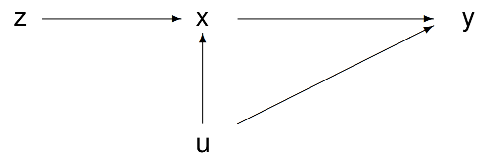

## Sketch of 2SLS

- If the instrument \(z\) satisfies the conditions of instrument relevance and exogeneity, the coefficient \(\beta_1\) can be estimated using an IV estimator called **two stage least squares (2SLS)**.
- As the name suggests, the two stage least squares estimator is calculated in two stages:
  - The first stage decomposes \(x\) into two components:
    - a problematic component that may be correlated with the regression error
    - and another, problem-free component that is uncorrelated with the error.
  - The second stage uses the problem-free component to estimate \(\beta_1\).

## Implementation of 2SLS

First stage:

- Estimate \(x_{1}=\gamma_0 + \gamma_1z\)
- (ALL coviariates that are used in the main estimation have to be included in this step!)
- Save \(\hat{x}_{1}\), the first stage estimate of $x_{1} $

Second stage:

- Regress \(y=\beta_0+\beta_{1}\hat{x}_{1}+u\)
- Note \(z\) only appears in the first stage, not in the second stage
- This is called the **exclusion restriction**

## Instrument for ice cream prices?

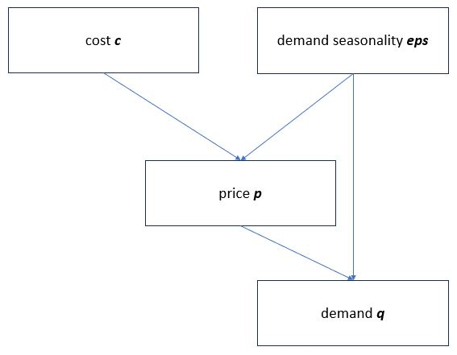

## Instruments in Ice Cream Example

\[q = \beta_0 + \beta_1 p + \beta_2 s + \varepsilon\]

- Check that both \(c\) and \(s\) are instruments for \(p\) (both satisfy the relevance and exogeneity condition)
- \(c\) is the required excluded instrument that is not part of the demand function.

## 2SLS with example of demand

Perform 2SLS running two OLS estimations.

1. Regress the \(p\) on instrument \(z\) and observed \(s\).

\[p = \gamma_0 + \gamma_1 c + \gamma_2 s + \eta\]

\[q=\beta_{0}+\beta_{1}\hat{p}+\beta_2 s+u\]

\(\hat \beta\) of this second stage is a unbiased estimator of \(\beta\).

## Generate our data

```r
T=1000
b1 = 100
b2 = -1

# demand shock
eps = rnorm(n = T,mean = 0,sd = 5)

# costs
c=runif(T,min = 10,max = 30)

# equation for optimal prices
p = (b1 + eps)/(2*b2)  + c / 2

# demand function
q = b1 + eps - b2*p
#lm(q~p)
```

## IV regression via 2SLS

Aim in first stage: get exogenous variation of prices due to costs

```r
# Price equation: p = gamma0 + gamma1*c + eta
reg1 <- lm(p ~ c)
reg1
```

```
##
## Call:
## lm(formula = p ~ c)
##
## Coefficients:
## (Intercept)            c
##      -49.76         0.48
```

```r
# Obtain predicted value: p.hat = gamma0.hat + gamma1.hat*c
p.hat = fitted(reg1)
```

## IV regression via 2SLS

Aim in second stage: use predicted values of first stage

```r
# Price equation: p = gamma0 + gamma1*c + eta
reg2 = lm(q~p.hat)
reg2
```

```
##
## Call:
## lm(formula = q ~ p.hat)
##
## Coefficients:
## (Intercept)        p.hat
##     103.673        1.083
```

## Better use ivreg from package AER

```r
# Price equation: p = gamma0 + gamma1*c + eta
library(AER)

ivreg(q~p | c)
```

```
##
## Call:
## ivreg(formula = q ~ p | c)
##
## Coefficients:
## (Intercept)            p
##     103.673        1.083
```